# Permutation test vignette: WPP 2024 development groups

This vignette demonstrates how to use the package functions to perform a two-group Monte Carlo permutation test comparing demographic indicators across development groups using country-level data.

The workflow shown includes:

- preparing a clean two-column dataset with `perm_data_extract()`,
- computing a two-sample Kolmogorov–Smirnov (KS) statistic with `perm_stat_ks()`,
- running a permutation test with `perm_test_two_group_ks()`, and
- visualizing the permutation distribution with `plot_perm_dist()`.

# Loading the Cleaned Dataset

We use the cleaned country-level dataset derived from the World Population Prospects 2024 Estimates data.

```r
# wpp_path <- "../Data/wpp_country_indicators_2023.csv"
# wpp <- readr::read_csv(wpp_path, show_col_types = FALSE)
data("wpp", package = "Sta380Project")

dplyr::glimpse(wpp)
```

```
#> Rows: 237
#> Columns: 6
#> $ country    <chr> "Burundi", "Comoros", "Djibouti", "Eritrea", "Ethiopia", "K…
#> $ year       <int> 2023, 2023, 2023, 2023, 2023, 2023, 2023, 2023, 2023, 2023,…
#> $ birth_rate <dbl> 33.667, 28.653, 20.769, 28.544, 31.903, 27.106, 32.095, 31.…
#> $ life_exp   <dbl> 63.651, 66.777, 65.987, 68.624, 67.315, 63.646, 63.632, 67.…
#> $ mortality  <dbl> 6.718, 7.196, 7.456, 6.047, 5.960, 7.211, 7.528, 5.363, 8.7…
#> $ dev_group  <chr> "Less developed", "Less developed", "Less developed", "Less…
```

# Preparing Data for a Selected Indicator

In this vignette we demonstrate the workflow using one indicator (birth rate). The same code applies to life expectancy or mortality rate by changing `indicator_col`.

```r
test_df <- perm_data_extract(wpp, birth_rate, dev_group)

dplyr::count(test_df, group)
```

```
#>            group   n
#> 1 Less developed 181
#> 2 More developed  56
```

```r
summary(test_df$outcome)
```

```
#>    Min. 1st Qu.  Median    Mean 3rd Qu.    Max.
#>   4.211   9.441  13.590  17.099  23.117  46.358
```

# Running the Permutation Test (KS statistic)

We run a two-sided permutation test using the KS statistic, which measures the maximum difference between the empirical CDFs of the two groups.

## Hypotheses

Let $F_M(x)$ be the distribution of the **More developed** group and $F_L(x)$ be the distribution of the **Less developed** group.

$$H_0: F_M(x) = F_L(x)$$
$$H_A: F_M(x) \neq F_L(x)$$

The observed test statistic is the Kolmogorov-Smirnov distance, defined as:

$$D_{obs} = \sup_x |F_M(x) -
F_L(x)|$$
We generate a permutation distribution by shuffling the group labels 𝐵 times.

```r
res <- perm_test_two_group_ks(
  df = test_df,
  B = 2000,
  seed = 1,
  alternative = "two.sided"
)

res$observed
```

```
#> [1] 0.738161
```

```r
res$p_value
```

```
#> [1] 0.0004997501
```

## Notes on the p-value

The function computes a Monte Carlo permutation p-value using the standard adjustment:

$p = \frac{\#\{\text{extreme permutations}\} + 1}{B + 1}$

This prevents reporting a p-value of exactly 0 when 𝐵is finite.

# Visualizing the Permutation Distribution

We plot the permutation distribution and highlight the observed KS statistic with a vertical line.

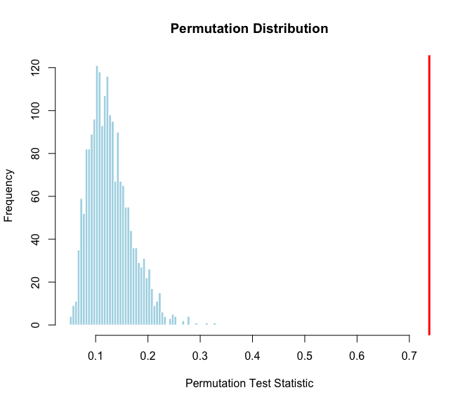

```r
plot_perm_dist(res, bins = 40)
```

Interpretation: The observed KS statistic lies far in the right tail of the permutation distribution, indicating that the observed difference between the two groups is much larger than would typically arise under random label assignment.

# Inspecting Outcome Distributions by Group

[figure not shown]

```r
outcome <- test_df$outcome
group <- test_df$group

groups <- as.character(group)
groups <- unique(groups)

if (length(groups) != 2) {
    stop("group must have exactly two levels. ")
}
xA <- outcome[group == groups[1]]
xB <- outcome[group == groups[2]]

ecdf_A <- stats::ecdf(xA)
ecdf_B <- stats::ecdf(xB)

plot(ecdf_A, col="blue", lwd=1,
       main="ECDF Comparison between two groups",
       xlab="Outcome",
       ylab="Cumulative Probability")

lines(ecdf_B, col="yellow", lwd=1)

legend("bottomright",
         legend=c("More developed","Less developed"),
         col=c("blue","yellow"),
         lwd=2)
```

# Conclusion (reject vs. fail to reject)

We conclude using a significance level α=0.05.

```r
alpha <- 0.05
p_value <- round(res$p_value, 4)

perm_test_conclusion(p_value, alpha)
```

Since 5e-04 (p-value) < 0.05 (alpha), we reject H0. The observed KS statistic is unlikely under random label assignment, providing statistical evidence that the indicator distribution differs between development groups in 2023.

# Generative AI Usage Statement

- **`permutation_functions.R`** Clarifying roxygen documentation formatting and understanding tidy evaluation syntax (using {{ }}) within the wrapper functions.
- **`plot_perm_dist.R`** Learning the usage of `invisible()` and `rgb()` functions.
- **`test-perm_function.R`** ChatGPT was used to suggest reasonable unit test cases and to explain the use of `skip_if_not()` for conditionally skipping wrapper tests when `perm_data_extract` is not yet implemented. Some test functions are named by the suggestion of AI.

# Bibliography

Basten, Stuart. 2013. “Re-Examining the Fertility Assumptions for Pacific Asia in the UN’s 2010 World Population Prospects.” *University of Oxford Department of Social Policy and Intervention, Barnett Papers in Social Research* 1.

Chang, Winston, Joe Cheng, JJ Allaire, Carson Sievert, Barret Schloerke, Garrick Aden-Buie, Yihui Xie, et al. 2025. “Shiny: Web Application Framework for r.” https://CRAN.R-project.org/package=shiny.

Müller, Kirill, and Hadley Wickham. 2023. *Tibble: Simple Data Frames*. https://CRAN.R-project.org/package=tibble.

O’Sullivan, Jane N. 2023. “Demographic Delusions: World Population Growth Is Exceeding Most Projections and Jeopardising Scenarios for Sustainable Futures.” *World* 4 (3): 545–68. https://doi.org/10.3390/world4030034.

R Core Team. 2024. “R: A Language and Environment for Statistical Computing.” https://www.R-project.org/.

United Nations, Department of Economic and Social Affairs, Population Division. 2024. *World Population Prospects 2024, Online Edition*. United Nations. https://population.un.org/wpp/.

United Nations Statistics Division. 2024. “Standard Country or Area Codes for Statistical Use (M49).” https://unstats.un.org/unsd/methodology/m49/.

Wickham, Hadley. 2011. “Testthat: Get Started with Testing.” *The R Journal* 3: 5–10. https://journal.r-project.org/articles/RJ-2011-002/.

Wickham, Hadley, Romain François, Lionel Henry, Kirill Müller, and Davis Vaughan. 2023. *Dplyr: A Grammar of Data Manipulation*. https://doi.org/10.32614/CRAN.package.dplyr.

Wickham, Hadley, Jim Hester, and Romain François. 2024. *Readr: Read Rectangular Text Data*. https://CRAN.R-project.org/package=readr.